```python
import qiskit
import numpy as np
import matplotlib.pyplot as plt
from qiskit.visualization import plot_histogram
from qiskit.providers.basic_provider import BasicSimulator

def run_circ(qc):
    backend = BasicSimulator()
    # If you do not specify the number of shots, the default is 1024
    qc_trans = qiskit.transpile(qc,backend=backend)
    result = backend.run(qc_trans, shots=2000,memory=True).result()

    # Extract the counts of 0 and 1 measurements
    counts = result.get_counts()
    return result
```

# The limits of current quantum computers for running algorithms

## QFT -- Quantum fourie transform

- Important cornerstone for many algorithms:
  - Shor: prime factoring
  - Faze estimation: estimate the eigenvalue of uniter transformations
  - HHL (Harrow-Hassidim-Lloyd): solve linear equation systems
- Transform a state into fourier base

## Exercise: Intro to QFT

```python
num_qubits = 10
# create the circuit with 'num_qubits' amount of qubits!
qc = qiskit.QuantumCircuit(num_qubits,num_qubits)
qc.x(0)
qc.x(2)

# Create the QFT circuit
qft = qiskit.circuit.library.QFT(num_qubits)
qft.draw()
```

```
     ┌──────┐
q_0: ┤0     ├
     │      │
q_1: ┤1     ├
     │      │
q_2: ┤2     ├
     │      │
q_3: ┤3     ├
     │      │
q_4: ┤4     ├
     │  QFT │
q_5: ┤5     ├
     │      │
q_6: ┤6     ├
     │      │
q_7: ┤7     ├
     │      │
q_8: ┤8     ├
     │      │
q_9: ┤9     ├
     └──────┘
```

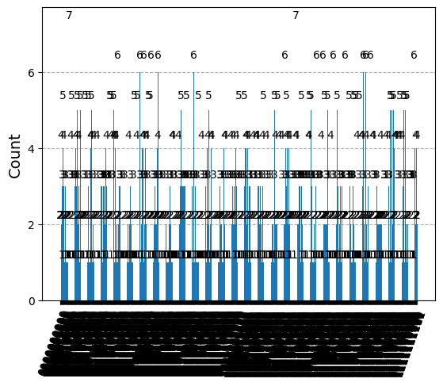

```python
# Add the QFT circuit to the perviously create circuit and add measurments
qc = qc.compose(qft)
qc.measure(range(num_qubits),range(num_qubits))

# Run the circuit
counts=run_circ(qc).get_counts()
plot_histogram(counts)
```

```python
# Create a circuit that converts a state into fourier basis and back using the last example
qc = qiskit.QuantumCircuit(num_qubits,num_qubits)
qc.x(0)
qc.x(2)
qc = qc.compose(qiskit.circuit.library.QFT(num_qubits,approximation_degree=0))
qc = qc.compose(qiskit.circuit.library.QFT(num_qubits,approximation_degree=0,inverse=True))
qc.measure(range(num_qubits),range(num_qubits))
qc.draw()
```

```
      ┌───┐┌──────┐┌──────────┐┌─┐
 q_0: ┤ X ├┤0     ├┤0         ├┤M├───────────────────────────
      └───┘│      ││          │└╥┘┌─┐
 q_1: ─────┤1     ├┤1         ├─╫─┤M├────────────────────────
      ┌───┐│      ││          │ ║ └╥┘┌─┐
 q_2: ┤ X ├┤2     ├┤2         ├─╫──╫─┤M├─────────────────────
      └───┘│      ││          │ ║  ║ └╥┘┌─┐
 q_3: ─────┤3     ├┤3         ├─╫──╫──╫─┤M├──────────────────
           │      ││          │ ║  ║  ║ └╥┘┌─┐
 q_4: ─────┤4     ├┤4         ├─╫──╫──╫──╫─┤M├───────────────
           │  QFT ││  IQFT_dg │ ║  ║  ║  ║ └╥┘┌─┐
 q_5: ─────┤5     ├┤5         ├─╫──╫──╫──╫──╫─┤M├────────────
           │      ││          │ ║  ║  ║  ║  ║ └╥┘┌─┐
 q_6: ─────┤6     ├┤6         ├─╫──╫──╫──╫──╫──╫─┤M├─────────
           │      ││          │ ║  ║  ║  ║  ║  ║ └╥┘┌─┐
 q_7: ─────┤7     ├┤7         ├─╫──╫──╫──╫──╫──╫──╫─┤M├──────
           │      ││          │ ║  ║  ║  ║  ║  ║  ║ └╥┘┌─┐
 q_8: ─────┤8     ├┤8         ├─╫──╫──╫──╫──╫──╫──╫──╫─┤M├───
           │      ││          │ ║  ║  ║  ║  ║  ║  ║  ║ └╥┘┌─┐
 q_9: ─────┤9     ├┤9         ├─╫──╫──╫──╫──╫──╫──╫──╫──╫─┤M├
           └──────┘└──────────┘ ║  ║  ║  ║  ║  ║  ║  ║  ║ └╥┘
c: 10/══════════════════════════╩══╩══╩══╩══╩══╩══╩══╩══╩══╩═
                                0  1  2  3  4  5  6  7  8  9
```

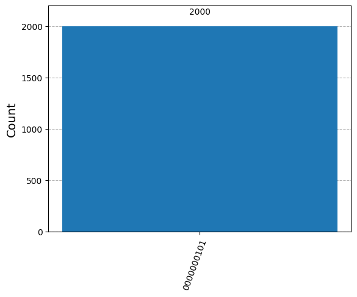

```python
# Try out the circuit

counts=run_circ(qc).get_counts()
plot_histogram(counts)
```

## QPE -- Quantum phase estimation

- Key part in molecular simulations and Shor algorithm
- Calculate the eigenvalue of a unitary
- Uses phasekickback:

[figure not shown]

where $|\pi_3\rangle = |\psi\rangle \otimes \left(\frac{1 + e^{2\pi i\theta}}{2}|0\rangle + \frac{1 - e^{2\pi i\theta}}{2}|1\rangle\right)$

## Estimate the phase of the P gate

- The matrix of the P gate is: $P(\phi) = \begin{pmatrix} 1 & 0 \\ 0 & e^{i\phi} \end{pmatrix}$
- in phase estimation we estimate:
- $\lambda$ using: $\phi=2*\pi*\lambda$

```python
num_qubits = 5
theta = 1/3
# Use the PhaseEstimation object to estimate the phase of the P gate
qc = qiskit.QuantumCircuit(num_qubits,num_qubits)
qc.x(num_qubits-1)
gate = qiskit.circuit.library.PhaseGate(2*np.pi*theta)
phase_qc = qiskit.circuit.library.PhaseEstimation(num_qubits-1,gate,iqft=qiskit.circuit.library.QFT(num_qubits-1,inverse=True))
phase_qc.decompose().draw()
```

```
        ┌───┐                                         ┌──────────┐
eval_0: ┤ H ├─■───────────────────────────────────────┤0         ├
        ├───┤ │                                       │          │
eval_1: ┤ H ├─┼─────────■─────────────────────────────┤1         ├
        ├───┤ │         │                             │  IQFT_dg │
eval_2: ┤ H ├─┼─────────┼─────────■───────────────────┤2         ├
        ├───┤ │         │         │                   │          │
eval_3: ┤ H ├─┼─────────┼─────────┼─────────■─────────┤3         ├
        └───┘ │P(2π/3)  │P(4π/3)  │P(8π/3)  │P(16π/3) └──────────┘
     q: ──────■─────────■─────────■─────────■─────────────────────
```

```python
# Add the measurments
qc.compose(phase_qc,inplace=True)
qc.measure(range(num_qubits-1),range(num_qubits-1))
qc.draw()
```

```
          ┌──────┐┌─┐
q_0: ─────┤0     ├┤M├─────────
          │      │└╥┘┌─┐
q_1: ─────┤1     ├─╫─┤M├──────
          │      │ ║ └╥┘┌─┐
q_2: ─────┤2 QPE ├─╫──╫─┤M├───
          │      │ ║  ║ └╥┘┌─┐
q_3: ─────┤3     ├─╫──╫──╫─┤M├
     ┌───┐│      │ ║  ║  ║ └╥┘
q_4: ┤ X ├┤4     ├─╫──╫──╫──╫─
     └───┘└──────┘ ║  ║  ║  ║
c: 5/══════════════╩══╩══╩══╩═
                   0  1  2  3
```

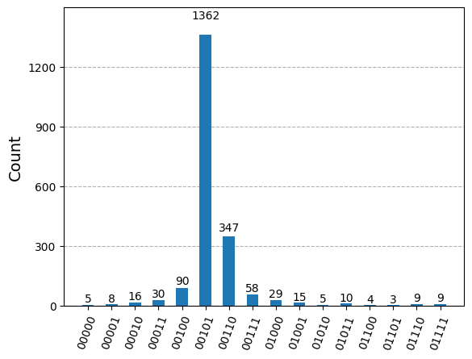

```python
# Run the circuit
counts=run_circ(qc).get_counts()
plot_histogram(counts)
```

```python
# Evaluate the results
most_probable = max(counts, key=counts.get)
integer = int(most_probable, 2)
print(f"{integer}")
print(f"Estimated value: {integer/(2**(num_qubits-1))}")
```

```
5
Estimated value: 0.3125
```

## Improving estimation

```python
theta = 1/np.e
import timeit
estimations = []
runtime = []
circ_compile_time = []

for num_qubits in range(3,24):
    start = timeit.default_timer()
    qc = qiskit.QuantumCircuit(num_qubits,num_qubits)
    qc.x(num_qubits-1)
    gate = qiskit.circuit.library.PhaseGate(2*np.pi*theta)
    phase_qc = qiskit.circuit.library.PhaseEstimation(num_qubits-1,gate,iqft=qiskit.circuit.library.QFT(num_qubits-1,inverse=True))
    qc.compose(phase_qc,inplace=True)
    qc.measure(range(num_qubits-1),range(num_qubits-1))

    circ_time = timeit.default_timer()

    counts=run_circ(qc).get_counts()
    most_probable = max(counts, key=counts.get)
    integer = int(most_probable, 2)
    t_est = integer/(2**(num_qubits-1))
    estimations.append(t_est)
    end = timeit.default_timer()


    runtime.append(end-circ_time)
    circ_compile_time.append(circ_time-start)
```

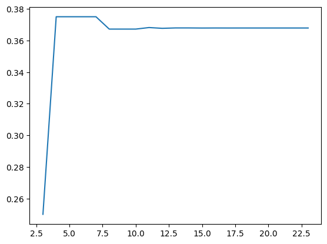

```python
plt.plot(range(3,24),estimations)
```

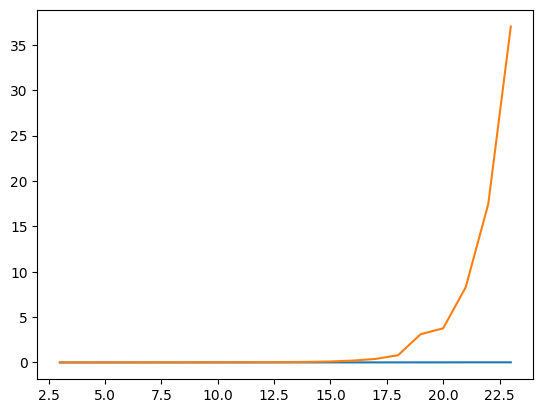

```python
plt.plot(range(3,24),circ_compile_time)
plt.plot(range(3,24),runtime)
```

```python
error = [abs(x-1/np.e)  for x in estimations]
```

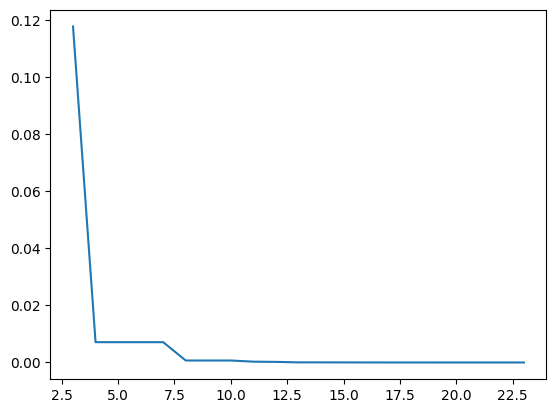

```python
plt.plot(range(3,24),error)
```

## Why don't we already using this?

- Number of usable quantum bits
- Coherence of quantum bits
- Simulation is hard, exponential memory usage
- Main stats of algorithms:
  - Needed qubits
  - Depth of circuit
  - Fidelity: how close we get to the expected value

```
Phase Estimation Benchmark Program - Qiskit
... execution starting at Apr 22, 2025 07:21:22 UTC
************
Executing [3] circuits with num_qubits = 3
************
Executing [3] circuits with num_qubits = 4
************
Average Circuit Algorithmic Depth, ξ (xi) for the 3 qubit group = 16, 0.316
Average Normalized Transpiled Depth, ξ (xi), 2q gates for the 3 qubit group = 18, 0.198, 4.333
Average Creation, Elapsed, Execution Time for the 3 qubit group = 0.012, 0.4, 0.013 secs
Average Transpiling, Validating, Running Times for group 3 = 0.001, 0.001, 0.001 secs
Average Hellinger, Normalized Fidelity for the 3 qubit group = 0.98, 0.973

************
Executing [3] circuits with num_qubits = 5
************
Average Circuit Algorithmic Depth, ξ (xi) for the 4 qubit group = 27, 0.353
Average Normalized Transpiled Depth, ξ (xi), 2q gates for the 4 qubit group = 30, 0.269, 10.333
Average Creation, Elapsed, Execution Time for the 4 qubit group = 0.016, 0.744, 0.004 secs
Average Transpiling, Validating, Running Times for group 4 = 0.001, 0.001, 0.001 secs
Average Hellinger, Normalized Fidelity for the 4 qubit group = 0.957, 0.95

************
Executing [3] circuits with num_qubits = 6
************
Average Circuit Algorithmic Depth, ξ (xi) for the 5 qubit group = 41, 0.377
Average Normalized Transpiled Depth, ξ (xi), 2q gates for the 5 qubit group = 43, 0.306, 17.667
Average Creation, Elapsed, Execution Time for the 5 qubit group = 0.021, 0.906, 0.005 secs
Average Transpiling, Validating, Running Times for group 5 = 0.001, 0.001, 0.001 secs
Average Hellinger, Normalized Fidelity for the 5 qubit group = 0.931, 0.926

************
Executing [3] circuits with num_qubits = 7
************
Average Circuit Algorithmic Depth, ξ (xi) for the 6 qubit group = 58, 0.395
Average Normalized Transpiled Depth, ξ (xi), 2q gates for the 6 qubit group = 61, 0.334, 27.667
Average Creation, Elapsed, Execution Time for the 6 qubit group = 0.021, 0.925, 0.02 secs
Average Transpiling, Validating, Running Times for group 6 = 0.001, 0.001, 0.001 secs
Average Hellinger, Normalized Fidelity for the 6 qubit group = 0.89, 0.887

```

[output cut: 75 more lines]

```
«q211_3: ────────────┤ Rz(-π/4) ├─────┼───────░──────┤ Rz(-π/2) ├─────┼──────»
«                    └──────────┘┌────┴─────┐ ░      └──────────┘┌────┴─────┐»
«q211_4: ────────────────────────┤ Rz(-π/8) ├─░──────────────────┤ Rz(-π/4) ├»
«                                └──────────┘ ░                  └──────────┘»
«         ░                   ░       ░
«q211_0: ─░───────────────────░───────░─
«         ░                   ░       ░
«q211_1: ─░───────────────────░───────░─
«         ░                   ░       ░
«q211_2: ─░───────────────────░───────░─
«         ░ ┌───┐             ░       ░
«q211_3: ─░─┤ H ├─────■───────░───────░─
«         ░ └───┘┌────┴─────┐ ░ ┌───┐ ░
«q211_4: ─░──────┤ Rz(-π/2) ├─░─┤ H ├─░─
«         ░      └──────────┘ ░ └───┘ ░
```

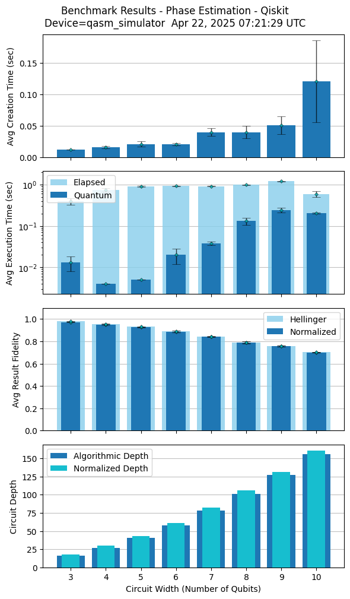

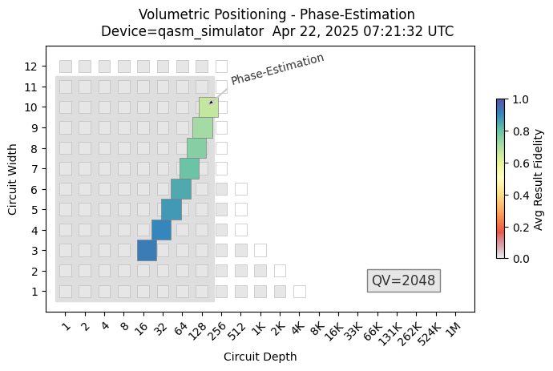

```python
import OtherStuff.pe_benchmark as pe_benchmark

min_qubits=2
max_qubits=10
skip_qubits=1
max_circuits=3
num_shots=1000
hub="ibm-q"; group="open"; project="main"
provider_backend = None
exec_options = {"resilience_level":0,"optimization_level": 0}

backend_id="qasm_simulator"
pe_benchmark.run(min_qubits=min_qubits, max_qubits=max_qubits, skip_qubits=skip_qubits,
                max_circuits=max_circuits, num_shots=num_shots,
                backend_id=backend_id, provider_backend=provider_backend,
                hub=hub, group=group, project=project, exec_options=exec_options)
```

```
Shor's Order Finding (1) Benchmark - Qiskit
... execution starting at Apr 22, 2025 07:21:33 UTC
************
Executing [1] circuits with num_qubits = 10
************
Average Circuit Algorithmic Depth, ξ (xi) for the 10 qubit group = 904, 0.536
Average Normalized Transpiled Depth, ξ (xi), 2q gates for the 10 qubit group = 2572, 0.423, 1380.0
Average Creation, Elapsed, Execution Time for the 10 qubit group = 0.522, 3.042, 2.544 secs
Average Transpiling, Validating, Running Times for group 10 = 0.001, 0.001, 0.001 secs
Average Hellinger, Normalized Fidelity for the 10 qubit group = 0.169, 0.051

... execution complete at Apr 22, 2025 07:21:37 UTC in 4.401 secs

Sample Circuit:
        ┌───┐ ░                                ┌──────────┐ ░ ┌──────────┐┌─┐»
q536_0: ┤ H ├─░────────────────────────────────┤0         ├─░─┤0         ├┤M├»
        ├───┤ ░                     ┌─────────┐│          │ ░ │          │└╥┘»
q536_1: ┤ H ├─░─────────────────────┤0        ├┤          ├─░─┤1         ├─╫─»
        ├───┤ ░           ┌────────┐│         ││          │ ░ │  inv_qft │ ║ »
q536_2: ┤ H ├─░───────────┤0       ├┤         ├┤          ├─░─┤2         ├─╫─»
        ├───┤ ░ ┌────────┐│        ││         ││          │ ░ │          │ ║ »
q536_3: ┤ H ├─░─┤0       ├┤        ├┤         ├┤          ├─░─┤3         ├─╫─»
        ├───┤ ░ │        ││        ││         ││          │ ░ └──────────┘ ║ »
q537_0: ┤ X ├─░─┤1       ├┤1       ├┤1        ├┤1         ├─░──────────────╫─»
        └───┘ ░ │        ││        ││         ││  C-U^256 │ ░              ║ »
q537_1: ──────░─┤2       ├┤2       ├┤2 C-U^16 ├┤2         ├─░──────────────╫─»
              ░ │        ││  C-U^4 ││         ││          │ ░              ║ »
q538_0: ──────░─┤3 C-U^2 ├┤3       ├┤3        ├┤3         ├─░──────────────╫─»
              ░ │        ││        ││         ││          │ ░              ║ »
q538_1: ──────░─┤4       ├┤4       ├┤4        ├┤4         ├─░──────────────╫─»
              ░ │        ││        ││         ││          │ ░              ║ »
q538_2: ──────░─┤5       ├┤5       ├┤5        ├┤5         ├─░──────────────╫─»
              ░ │        ││        ││         ││          │ ░              ║ »
q538_3: ──────░─┤6       ├┤6       ├┤6        ├┤6         ├─░──────────────╫─»
              ░ └────────┘└────────┘└─────────┘└──────────┘ ░              ║ »
 c24: 4/═══════════════════════════════════════════════════════════════════╩═»
                                                                           0 »
«
«q536_0: ─────────
«        ┌─┐
```

[output cut: 85 more lines]

```
q_0: ──┤ P(π) ├─
     ┌─┴──────┴┐
q_1: ┤ P(3π/2) ├
     ├─────────┤
q_2: ┤ P(3π/4) ├
     └─────────┘

QFT Circuit =
              ░                  ░                       ┌───┐ ░
q716_0: ──────░──────────────────░──────■──────────■─────┤ H ├─░─
              ░            ┌───┐ ░      │     ┌────┴────┐└───┘ ░
q716_1: ──────░──────■─────┤ H ├─░──────┼─────┤ Rz(π/2) ├──────░─
        ┌───┐ ░ ┌────┴────┐└───┘ ░ ┌────┴────┐└─────────┘      ░
q716_2: ┤ H ├─░─┤ Rz(π/2) ├──────░─┤ Rz(π/4) ├─────────────────░─
        └───┘ ░ └─────────┘      ░ └─────────┘                 ░
```

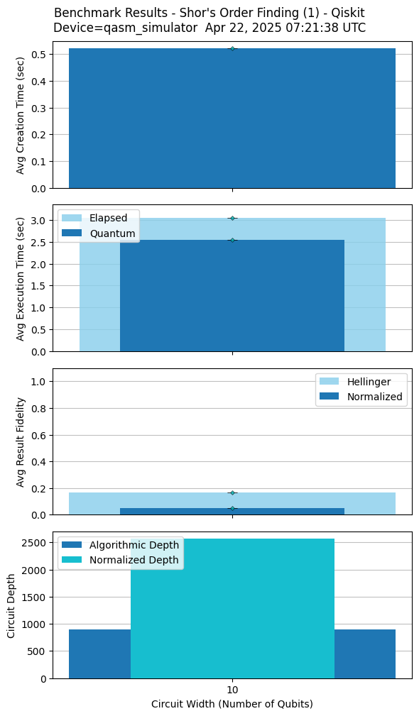

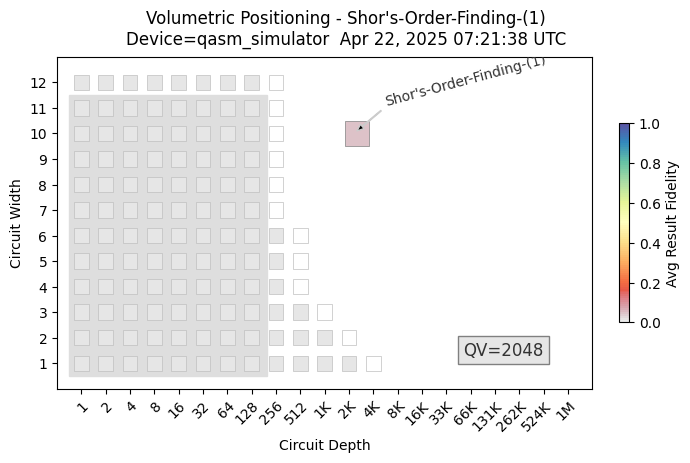

```python
import OtherStuff.shors_benchmark as shors_benchmark
shors_benchmark.run(min_qubits=min_qubits, max_qubits=max_qubits, max_circuits=1, num_shots=num_shots,
                method=1,
                backend_id=backend_id, provider_backend=provider_backend,
                hub=hub, group=group, project=project, exec_options=exec_options)
```

```python
from qiskit_ibm_runtime import QiskitRuntimeService
from qiskit_ibm_runtime.fake_provider import FakeAlmadenV2
from qiskit_ibm_runtime. fake_provider. backends.brisbane.fake_brisbane import FakeBrisbane
service = QiskitRuntimeService(channel="ibm_quantum",
    token="")

service.backends()
```

```
[<IBMBackend('ibm_brisbane')>, <IBMBackend('ibm_sherbrooke')>]
```

```python
backend = service.backend("ibm_sherbrooke")
backend
```

```
<IBMBackend('ibm_sherbrooke')>
```

```python
from qiskit_ibm_runtime.fake_provider import FakeAlmadenV2
from qiskit_ibm_runtime. fake_provider. backends.brisbane.fake_brisbane import FakeBrisbane
import OtherStuff.pe_benchmark as pe_benchmark


min_qubits=20
max_qubits=22
skip_qubits=1
max_circuits=1
num_shots=1000
hub="ibm-q"; group="open"; project="main"
provider_backend = backend
exec_options = {}

backend_id=str(provider_backend.name)
pe_benchmark.run(min_qubits=min_qubits, max_qubits=max_qubits, skip_qubits=skip_qubits,
                max_circuits=max_circuits, num_shots=num_shots,
                backend_id=backend_id, provider_backend=provider_backend,
                hub=hub, group=group, project=project, exec_options=exec_options)
```

[output not shown]

[output cut: 18 more lines]

```
«                                └──────────┘ ░                  └──────────┘»
«         ░                   ░       ░
«q211_0: ─░───────────────────░───────░─
«         ░                   ░       ░
«q211_1: ─░───────────────────░───────░─
«         ░                   ░       ░
«q211_2: ─░───────────────────░───────░─
«         ░ ┌───┐             ░       ░
«q211_3: ─░─┤ H ├─────■───────░───────░─
«         ░ └───┘┌────┴─────┐ ░ ┌───┐ ░
«q211_4: ─░──────┤ Rz(-π/2) ├─░─┤ H ├─░─
«         ░      └──────────┘ ░ └───┘ ░

Benchmark Results - Phase Estimation - Qiskit
     ****** NO RESULTS ******
```

## Simulate using data from real quantum computers

```python
# Hasznalt
from qiskit_ibm_runtime. fake_provider. backends.sherbrooke.fake_sherbrooke import FakeSherbrooke
# Heron R1
from qiskit_ibm_runtime. fake_provider. backends.torino.fake_torino import FakeTorino
from qiskit_ibm_runtime.fake_provider.backends.almaden.fake_almaden import FakeAlmadenV2
from qiskit_ibm_runtime.fake_provider.backends.manhattan.fake_manhattan import FakeManhattanV2
from qiskit_ibm_runtime.fake_provider.backends.casablanca.fake_casablanca import FakeCasablancaV2
import OtherStuff.pe_benchmark as pe_benchmark
```

```
Phase Estimation Benchmark Program - Qiskit
... execution starting at Apr 22, 2025 07:21:58 UTC
************
Executing [3] circuits with num_qubits = 3
************
Executing [3] circuits with num_qubits = 4
************
Average Circuit Algorithmic Depth, ξ (xi) for the 3 qubit group = 16, 0.316
Average Normalized Transpiled Depth, ξ (xi), 2q gates for the 3 qubit group = 18, 0.198, 4.333
Average Creation, Elapsed, Execution Time for the 3 qubit group = 0.018, 5.053, 1.796 secs
Average Transpiling, Validating, Running Times for group 3 = 0.001, 0.001, 0.001 secs
Average Hellinger, Normalized Fidelity for the 3 qubit group = 0.963, 0.95

************
Executing [3] circuits with num_qubits = 5
************
Average Circuit Algorithmic Depth, ξ (xi) for the 4 qubit group = 27, 0.353
Average Normalized Transpiled Depth, ξ (xi), 2q gates for the 4 qubit group = 30, 0.269, 10.333
Average Creation, Elapsed, Execution Time for the 4 qubit group = 0.028, 4.183, 1.22 secs
Average Transpiling, Validating, Running Times for group 4 = 0.001, 0.001, 0.001 secs
Average Hellinger, Normalized Fidelity for the 4 qubit group = 0.897, 0.883

************
Executing [3] circuits with num_qubits = 6
************
Average Circuit Algorithmic Depth, ξ (xi) for the 5 qubit group = 41, 0.377
Average Normalized Transpiled Depth, ξ (xi), 2q gates for the 5 qubit group = 43, 0.306, 17.667
Average Creation, Elapsed, Execution Time for the 5 qubit group = 0.036, 3.542, 1.213 secs
Average Transpiling, Validating, Running Times for group 5 = 0.001, 0.001, 0.001 secs
Average Hellinger, Normalized Fidelity for the 5 qubit group = 0.841, 0.83

************
Executing [3] circuits with num_qubits = 7
************
Average Circuit Algorithmic Depth, ξ (xi) for the 6 qubit group = 58, 0.395
Average Normalized Transpiled Depth, ξ (xi), 2q gates for the 6 qubit group = 61, 0.334, 27.667
Average Creation, Elapsed, Execution Time for the 6 qubit group = 0.035, 3.722, 1.242 secs
Average Transpiling, Validating, Running Times for group 6 = 0.001, 0.001, 0.001 secs
Average Hellinger, Normalized Fidelity for the 6 qubit group = 0.72, 0.711

```

[output cut: 75 more lines]

```
«q3160_3: ────────────┤ Rz(-π/4) ├─────┼───────░──────┤ Rz(-π/2) ├─────┼──────»
«                     └──────────┘┌────┴─────┐ ░      └──────────┘┌────┴─────┐»
«q3160_4: ────────────────────────┤ Rz(-π/8) ├─░──────────────────┤ Rz(-π/4) ├»
«                                 └──────────┘ ░                  └──────────┘»
«          ░                   ░       ░
«q3160_0: ─░───────────────────░───────░─
«          ░                   ░       ░
«q3160_1: ─░───────────────────░───────░─
«          ░                   ░       ░
«q3160_2: ─░───────────────────░───────░─
«          ░ ┌───┐             ░       ░
«q3160_3: ─░─┤ H ├─────■───────░───────░─
«          ░ └───┘┌────┴─────┐ ░ ┌───┐ ░
«q3160_4: ─░──────┤ Rz(-π/2) ├─░─┤ H ├─░─
«          ░      └──────────┘ ░ └───┘ ░
```

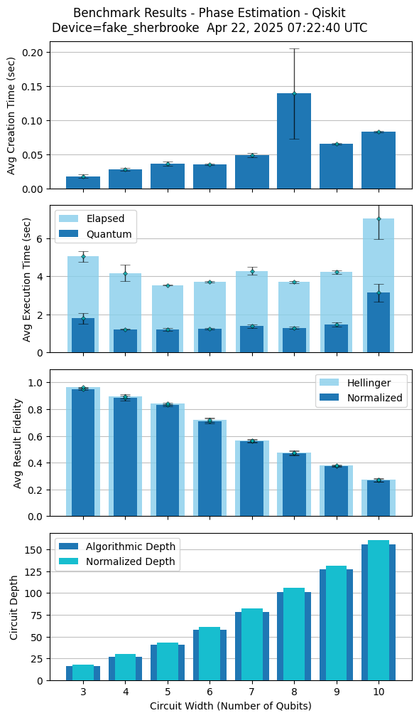

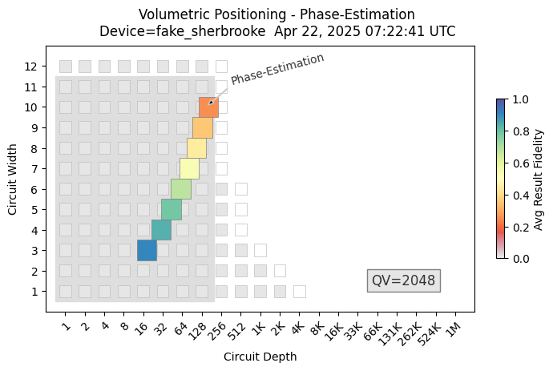

```python
min_qubits=2
max_qubits=10
skip_qubits=1
max_circuits=3
num_shots=1000
hub="ibm-q"; group="open"; project="main"
provider_backend = FakeSherbrooke()

backend_id=str(provider_backend.name)
pe_benchmark.run(min_qubits=min_qubits, max_qubits=max_qubits, skip_qubits=skip_qubits,
                max_circuits=max_circuits, num_shots=num_shots,
                backend_id=backend_id, provider_backend=provider_backend,
                hub=hub, group=group, project=project, exec_options=exec_options)
```

## Choosing the next QPU to test:

- Falcon R4 Processors (7): FakeCasablancaV2
- Falcon Processor (27): FakeAlmadenV2
- Hummingbird Processors (65): FakeManhattanV2
- !Eagle Processors (127): FakeSherbrooke
- !Heron R1 (156): FakeTorino

```
Phase Estimation Benchmark Program - Qiskit
... execution starting at Apr 22, 2025 07:22:43 UTC
************
Executing [3] circuits with num_qubits = 3
************
Executing [3] circuits with num_qubits = 4
************
Average Circuit Algorithmic Depth, ξ (xi) for the 3 qubit group = 16, 0.316
Average Normalized Transpiled Depth, ξ (xi), 2q gates for the 3 qubit group = 18, 0.198, 4.333
Average Creation, Elapsed, Execution Time for the 3 qubit group = 0.014, 4.183, 1.25 secs
Average Transpiling, Validating, Running Times for group 3 = 0.001, 0.001, 0.001 secs
Average Hellinger, Normalized Fidelity for the 3 qubit group = 0.944, 0.925

************
Executing [3] circuits with num_qubits = 5
************
Average Circuit Algorithmic Depth, ξ (xi) for the 4 qubit group = 27, 0.353
Average Normalized Transpiled Depth, ξ (xi), 2q gates for the 4 qubit group = 30, 0.269, 10.333
Average Creation, Elapsed, Execution Time for the 4 qubit group = 0.024, 3.504, 1.294 secs
Average Transpiling, Validating, Running Times for group 4 = 0.001, 0.001, 0.001 secs
Average Hellinger, Normalized Fidelity for the 4 qubit group = 0.831, 0.807

************
Executing [3] circuits with num_qubits = 6
************
Average Circuit Algorithmic Depth, ξ (xi) for the 5 qubit group = 41, 0.377
Average Normalized Transpiled Depth, ξ (xi), 2q gates for the 5 qubit group = 43, 0.306, 17.667
Average Creation, Elapsed, Execution Time for the 5 qubit group = 0.167, 3.691, 1.196 secs
Average Transpiling, Validating, Running Times for group 5 = 0.001, 0.001, 0.001 secs
Average Hellinger, Normalized Fidelity for the 5 qubit group = 0.707, 0.688

************
Executing [3] circuits with num_qubits = 7
************
Average Circuit Algorithmic Depth, ξ (xi) for the 6 qubit group = 58, 0.395
Average Normalized Transpiled Depth, ξ (xi), 2q gates for the 6 qubit group = 61, 0.334, 27.667
Average Creation, Elapsed, Execution Time for the 6 qubit group = 0.042, 3.958, 1.411 secs
Average Transpiling, Validating, Running Times for group 6 = 0.001, 0.001, 0.001 secs
Average Hellinger, Normalized Fidelity for the 6 qubit group = 0.598, 0.585

```

[output cut: 75 more lines]

```
«q4802_3: ────────────┤ Rz(-π/4) ├─────┼───────░──────┤ Rz(-π/2) ├─────┼──────»
«                     └──────────┘┌────┴─────┐ ░      └──────────┘┌────┴─────┐»
«q4802_4: ────────────────────────┤ Rz(-π/8) ├─░──────────────────┤ Rz(-π/4) ├»
«                                 └──────────┘ ░                  └──────────┘»
«          ░                   ░       ░
«q4802_0: ─░───────────────────░───────░─
«          ░                   ░       ░
«q4802_1: ─░───────────────────░───────░─
«          ░                   ░       ░
«q4802_2: ─░───────────────────░───────░─
«          ░ ┌───┐             ░       ░
«q4802_3: ─░─┤ H ├─────■───────░───────░─
«          ░ └───┘┌────┴─────┐ ░ ┌───┐ ░
«q4802_4: ─░──────┤ Rz(-π/2) ├─░─┤ H ├─░─
«          ░      └──────────┘ ░ └───┘ ░
```

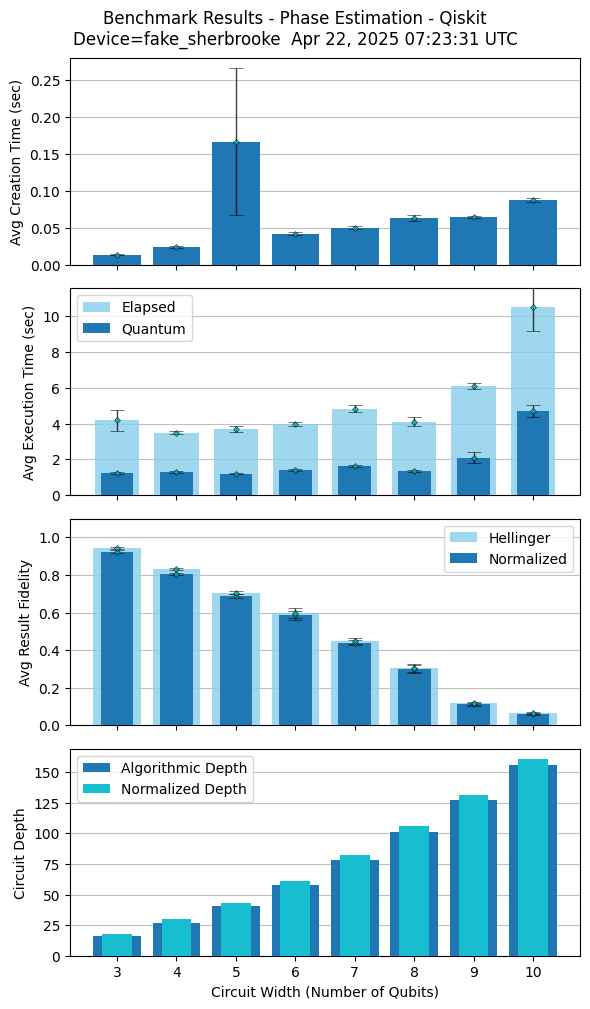

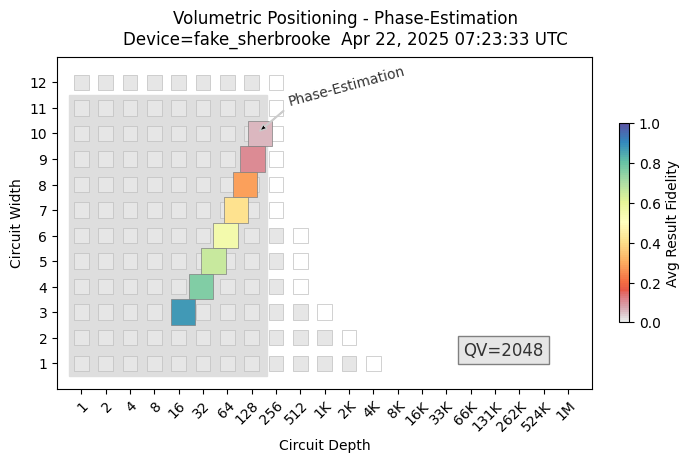

```python
provider_backend = FakeSherbrooke()
backend_id=str(provider_backend.name)
exec_options = {"resilience_level":0,"optimization_level": 0}

pe_benchmark.run(min_qubits=min_qubits, max_qubits=max_qubits, skip_qubits=skip_qubits,
                max_circuits=max_circuits, num_shots=num_shots,
                backend_id=backend_id, provider_backend=provider_backend,
                hub=hub, group=group, project=project, exec_options=exec_options)
```

## Solution: Resilience

Levels:

- 0 -- No correction
- 1 -- Minimal error correction: readout error reduction using TREX (Twirled Readout Error eXtinction)
- 2 -- level 1 + ZNE (Zero noise extrapolation)

```
Phase Estimation Benchmark Program - Qiskit
... execution starting at Apr 22, 2025 07:23:34 UTC
************
Executing [3] circuits with num_qubits = 3
************
Executing [3] circuits with num_qubits = 4
************
Average Circuit Algorithmic Depth, ξ (xi) for the 3 qubit group = 16, 0.316
Average Normalized Transpiled Depth, ξ (xi), 2q gates for the 3 qubit group = 18, 0.198, 4.333
Average Creation, Elapsed, Execution Time for the 3 qubit group = 0.018, 4.228, 1.314 secs
Average Transpiling, Validating, Running Times for group 3 = 0.001, 0.001, 0.001 secs
Average Hellinger, Normalized Fidelity for the 3 qubit group = 0.967, 0.956

************
Executing [3] circuits with num_qubits = 5
************
Average Circuit Algorithmic Depth, ξ (xi) for the 4 qubit group = 27, 0.353
Average Normalized Transpiled Depth, ξ (xi), 2q gates for the 4 qubit group = 30, 0.269, 10.333
Average Creation, Elapsed, Execution Time for the 4 qubit group = 0.028, 4.586, 1.656 secs
Average Transpiling, Validating, Running Times for group 4 = 0.001, 0.001, 0.001 secs
Average Hellinger, Normalized Fidelity for the 4 qubit group = 0.901, 0.887

************
Executing [3] circuits with num_qubits = 6
************
Average Circuit Algorithmic Depth, ξ (xi) for the 5 qubit group = 41, 0.377
Average Normalized Transpiled Depth, ξ (xi), 2q gates for the 5 qubit group = 43, 0.306, 17.667
Average Creation, Elapsed, Execution Time for the 5 qubit group = 0.03, 4.461, 1.34 secs
Average Transpiling, Validating, Running Times for group 5 = 0.001, 0.001, 0.001 secs
Average Hellinger, Normalized Fidelity for the 5 qubit group = 0.845, 0.835

************
Executing [3] circuits with num_qubits = 7
************
Average Circuit Algorithmic Depth, ξ (xi) for the 6 qubit group = 58, 0.395
Average Normalized Transpiled Depth, ξ (xi), 2q gates for the 6 qubit group = 61, 0.334, 27.667
Average Creation, Elapsed, Execution Time for the 6 qubit group = 0.139, 3.759, 1.192 secs
Average Transpiling, Validating, Running Times for group 6 = 0.001, 0.001, 0.001 secs
Average Hellinger, Normalized Fidelity for the 6 qubit group = 0.684, 0.673

```

[output cut: 93 more lines]

```
«q7058_3: ────────────┤ Rz(-π/4) ├─────┼───────░──────┤ Rz(-π/2) ├─────┼──────»
«                     └──────────┘┌────┴─────┐ ░      └──────────┘┌────┴─────┐»
«q7058_4: ────────────────────────┤ Rz(-π/8) ├─░──────────────────┤ Rz(-π/4) ├»
«                                 └──────────┘ ░                  └──────────┘»
«          ░                   ░       ░
«q7058_0: ─░───────────────────░───────░─
«          ░                   ░       ░
«q7058_1: ─░───────────────────░───────░─
«          ░                   ░       ░
«q7058_2: ─░───────────────────░───────░─
«          ░ ┌───┐             ░       ░
«q7058_3: ─░─┤ H ├─────■───────░───────░─
«          ░ └───┘┌────┴─────┐ ░ ┌───┐ ░
«q7058_4: ─░──────┤ Rz(-π/2) ├─░─┤ H ├─░─
«          ░      └──────────┘ ░ └───┘ ░
```

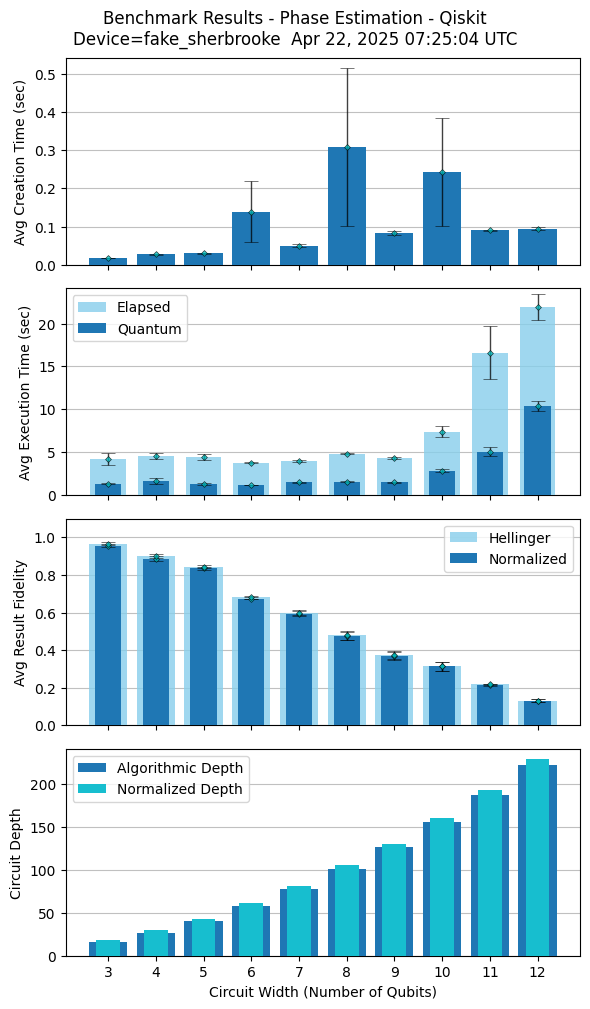

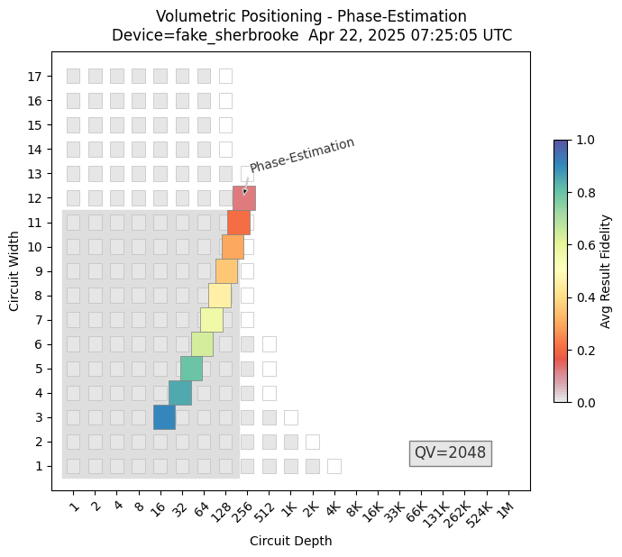

```python
min_qubits=2
max_qubits=12
skip_qubits=1
max_circuits=3
provider_backend = FakeSherbrooke()
exec_options = {"resilience_level":1,"optimization_level": 3}
backend_id=str(provider_backend.name)
pe_benchmark.run(min_qubits=min_qubits, max_qubits=max_qubits, skip_qubits=skip_qubits,
                max_circuits=max_circuits, num_shots=num_shots,
                backend_id=backend_id, provider_backend=provider_backend,
                hub=hub, group=group, project=project, exec_options=exec_options)
```

## Qiskit transpiler:

[figure not shown]

- init
- **layout**
- **routing**
- translation
- **optimization**
- scheduling

## Problem1:

```python
qiskit.circuit.library.QFT(10).decompose().draw()
```

```
                                                                           »
q_0: ──────────────────────────────────────────────────────────────────────»
                                                                           »
q_1: ──────────────────────────────────────────────────────────────────────»
                                                                           »
q_2: ──────────────────────────────────────────────────────────────────────»
                                                                           »
q_3: ──────────────────────────────────────────────────────────────────────»
                                                                           »
q_4: ──────────────────────────────────────────────────────────────────────»
                                                                           »
q_5: ─────────────────────────────────────────────────────────────■────────»
                                                                  │        »
q_6: ──────────────────────────────────────■─────────────■────────┼────────»
                                           │       ┌───┐ │        │        »
q_7: ────────────────────■────────■────────┼───────┤ H ├─┼────────┼────────»
                   ┌───┐ │        │P(π/2)  │       └───┘ │P(π/4)  │        »
q_8: ──────■───────┤ H ├─┼────────■────────┼─────────────■────────┼────────»
     ┌───┐ │P(π/2) └───┘ │P(π/4)           │P(π/8)                │P(π/16) »
q_9: ┤ H ├─■─────────────■─────────────────■──────────────────────■────────»
     └───┘                                                                 »
«                                                                            »
«q_0: ───────────────────────────────────────────────────────────────────────»
«                                                                            »
«q_1: ───────────────────────────────────────────────────────────────────────»
«                                                                            »
«q_2: ───────────────────────────────────────────────────────────────────────»
«                                                                            »
«q_3: ─────────────────────────────────────────────────────■─────────────────»
«                                                          │                 »
«q_4: ───────────────────■───────────────────────■─────────┼─────────────────»
«                        │                       │         │                 »
«q_5: ──────────■────────┼──────────────■────────┼─────────┼─────────■───────»
«               │        │        ┌───┐ │        │         │         │P(π/2) »
«q_6: ─■────────┼────────┼────────┤ H ├─┼────────┼─────────┼─────────■───────»
«      │P(π/2)  │        │        └───┘ │P(π/4)  │         │                 »
«q_7: ─■────────┼────────┼──────────────■────────┼─────────┼─────────────────»
«               │P(π/8)  │                       │P(π/16)  │                 »
«q_8: ──────────■────────┼───────────────────────■─────────┼─────────────────»
«                        │P(π/32)                          │P(π/64)          »
```

[output cut: 92 more lines]

```
«     └───┘ │P(π/4)  │                  │P(π/8)                   │      │   │
«q_3: ──────■────────┼──────────────────■─────────X───────────────┼──────┼───┼─
«                    │P(π/16)                     │               │      │   │
«q_4: ───────────────■────────────X───────────────┼───────────────┼──────┼───┼─
«                                 │               │               │      │   │
«q_5: ────────────────────────────X───────────────┼───────────────┼──────┼───┼─
«                                                 │               │      │   │
«q_6: ────────────────────────────────────────────X───────────────┼──────┼───┼─
«                                                                 │      │   │
«q_7: ────────────────────────────────────────────────────────────X──────┼───┼─
«                                                                        │   │
«q_8: ───────────────────────────────────────────────────────────────────X───┼─
«                                                                            │
«q_9: ───────────────────────────────────────────────────────────────────────X─
«
```

[figure not shown]

## Transpiler: layout

Transpile the circuit to the selected QPU architecture

[figure not shown]

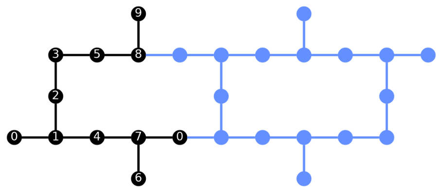

```python
from qiskit.visualization import plot_circuit_layout
from qiskit.providers.fake_provider import Fake27QPulseV1
backend = Fake27QPulseV1()
qc_orig = qiskit.circuit.library.PhaseEstimation(10,qiskit.circuit.library.PhaseGate(2*np.pi))
qc_layout = qiskit.transpile(qc_orig,backend=backend,optimization_level=0,routing_method=None)

plot_circuit_layout(qc_layout,backend)
```

## Problem2: Neighbourhood

```python
qc_test = qiskit.QuantumCircuit(15)
qc_test.h(0)
for i in range(1,15):
    qc_test.cx(0,i)

qc_test.measure_all()
qc_test.draw()
```

```
         ┌───┐                                                                 »
    q_0: ┤ H ├──■────■────■────■────■────■────■────■────■────■────■────■────■──»
         └───┘┌─┴─┐  │    │    │    │    │    │    │    │    │    │    │    │  »
    q_1: ─────┤ X ├──┼────┼────┼────┼────┼────┼────┼────┼────┼────┼────┼────┼──»
              └───┘┌─┴─┐  │    │    │    │    │    │    │    │    │    │    │  »
    q_2: ──────────┤ X ├──┼────┼────┼────┼────┼────┼────┼────┼────┼────┼────┼──»
                   └───┘┌─┴─┐  │    │    │    │    │    │    │    │    │    │  »
    q_3: ───────────────┤ X ├──┼────┼────┼────┼────┼────┼────┼────┼────┼────┼──»
                        └───┘┌─┴─┐  │    │    │    │    │    │    │    │    │  »
    q_4: ────────────────────┤ X ├──┼────┼────┼────┼────┼────┼────┼────┼────┼──»
                             └───┘┌─┴─┐  │    │    │    │    │    │    │    │  »
    q_5: ─────────────────────────┤ X ├──┼────┼────┼────┼────┼────┼────┼────┼──»
                                  └───┘┌─┴─┐  │    │    │    │    │    │    │  »
    q_6: ──────────────────────────────┤ X ├──┼────┼────┼────┼────┼────┼────┼──»
                                       └───┘┌─┴─┐  │    │    │    │    │    │  »
    q_7: ───────────────────────────────────┤ X ├──┼────┼────┼────┼────┼────┼──»
                                            └───┘┌─┴─┐  │    │    │    │    │  »
    q_8: ────────────────────────────────────────┤ X ├──┼────┼────┼────┼────┼──»
                                                 └───┘┌─┴─┐  │    │    │    │  »
    q_9: ─────────────────────────────────────────────┤ X ├──┼────┼────┼────┼──»
                                                      └───┘┌─┴─┐  │    │    │  »
   q_10: ──────────────────────────────────────────────────┤ X ├──┼────┼────┼──»
                                                           └───┘┌─┴─┐  │    │  »
   q_11: ───────────────────────────────────────────────────────┤ X ├──┼────┼──»
                                                                └───┘┌─┴─┐  │  »
   q_12: ────────────────────────────────────────────────────────────┤ X ├──┼──»
                                                                     └───┘┌─┴─┐»
   q_13: ─────────────────────────────────────────────────────────────────┤ X ├»
                                                                          └───┘»
   q_14: ──────────────────────────────────────────────────────────────────────»
                                                                               »
meas: 15/══════════════════════════════════════════════════════════════════════»
                                                                               »
«               ░ ┌─┐
«    q_0: ──■───░─┤M├──────────────────────────────────────────
«           │   ░ └╥┘┌─┐
«    q_1: ──┼───░──╫─┤M├───────────────────────────────────────
«           │   ░  ║ └╥┘┌─┐
«    q_2: ──┼───░──╫──╫─┤M├────────────────────────────────────
«           │   ░  ║  ║ └╥┘┌─┐
```

[output cut: 11 more lines]

```
«           │   ░  ║  ║  ║  ║  ║  ║  ║  ║ └╥┘┌─┐
«    q_9: ──┼───░──╫──╫──╫──╫──╫──╫──╫──╫──╫─┤M├───────────────
«           │   ░  ║  ║  ║  ║  ║  ║  ║  ║  ║ └╥┘┌─┐
«   q_10: ──┼───░──╫──╫──╫──╫──╫──╫──╫──╫──╫──╫─┤M├────────────
«           │   ░  ║  ║  ║  ║  ║  ║  ║  ║  ║  ║ └╥┘┌─┐
«   q_11: ──┼───░──╫──╫──╫──╫──╫──╫──╫──╫──╫──╫──╫─┤M├─────────
«           │   ░  ║  ║  ║  ║  ║  ║  ║  ║  ║  ║  ║ └╥┘┌─┐
«   q_12: ──┼───░──╫──╫──╫──╫──╫──╫──╫──╫──╫──╫──╫──╫─┤M├──────
«           │   ░  ║  ║  ║  ║  ║  ║  ║  ║  ║  ║  ║  ║ └╥┘┌─┐
«   q_13: ──┼───░──╫──╫──╫──╫──╫──╫──╫──╫──╫──╫──╫──╫──╫─┤M├───
«         ┌─┴─┐ ░  ║  ║  ║  ║  ║  ║  ║  ║  ║  ║  ║  ║  ║ └╥┘┌─┐
«   q_14: ┤ X ├─░──╫──╫──╫──╫──╫──╫──╫──╫──╫──╫──╫──╫──╫──╫─┤M├
«         └───┘ ░  ║  ║  ║  ║  ║  ║  ║  ║  ║  ║  ║  ║  ║  ║ └╥┘
«meas: 15/═════════╩══╩══╩══╩══╩══╩══╩══╩══╩══╩══╩══╩══╩══╩══╩═
«                  0  1  2  3  4  5  6  7  8  9  10 11 12 13 14
```

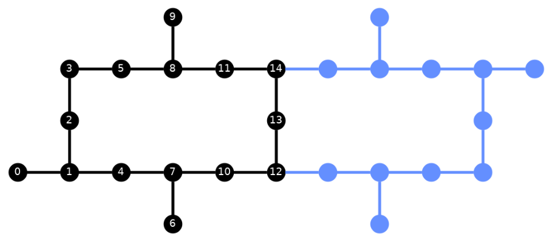

```python
qc_routed = qiskit.transpile(qc_test,backend=backend,optimization_level=0)
plot_circuit_layout(qc_routed,backend)
```

## Soution: Routing

- Swap gates
- SabreSwap algorithm to find a good but not perfect solution

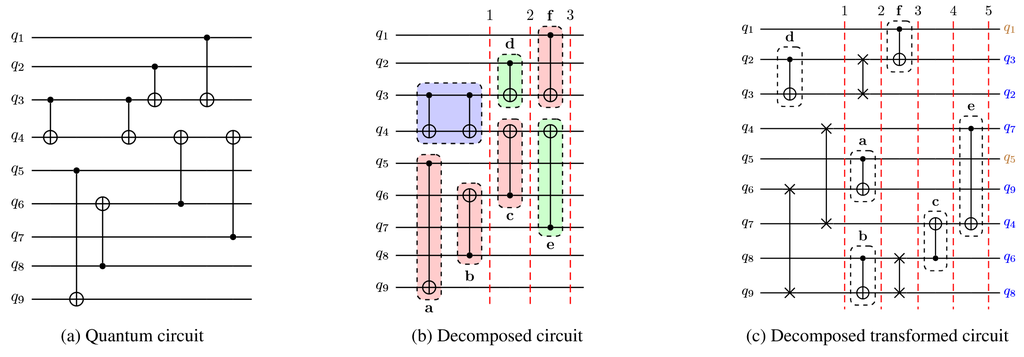

```python
qc_routed.draw(fold=-1,idle_wires=False)
```

```
global phase: π/4
           ┌─────────┐┌────┐┌─────────┐                              ┌───┐                                                                                                                                                                                                                                  …
  q_0 -> 0 ┤ Rz(π/2) ├┤ √X ├┤ Rz(π/2) ├──■───────────────────■────■──┤ X ├──■───────────────────────────────────────────────────────────────────────────────────────────────────────────────────────────────────────────────────────────────────────────────────────────────────────────────────────────────…
           └─────────┘└────┘└─────────┘┌─┴─┐┌───┐     ┌───┐┌─┴─┐┌─┴─┐└─┬─┘┌─┴─┐               ┌───┐          ┌───┐               ┌───┐                    ┌───┐┌───┐     ┌───┐┌───┐                                                                                                                         …
  q_1 -> 1 ────────────────────────────┤ X ├┤ X ├──■──┤ X ├┤ X ├┤ X ├──■──┤ X ├──■────■────■──┤ X ├──■───────┤ X ├───────■───────┤ X ├────────────────────┤ X ├┤ X ├──■──┤ X ├┤ X ├─────────────────────────────────────────────────────────────────────────────────────────────────────────────────────────…
                                       └───┘└─┬─┘┌─┴─┐└─┬─┘├───┤└───┘┌───┐└───┘┌─┴─┐  │  ┌─┴─┐└─┬─┘┌─┴─┐     └─┬─┘┌───┐  │       └─┬─┘     ┌───┐     ┌───┐└─┬─┘└─┬─┘  │  └─┬─┘└─┬─┘     ┌───┐                                                                                                               …
  q_2 -> 2 ───────────────────────────────────■──┤ X ├──■──┤ X ├──■──┤ X ├─────┤ X ├──┼──┤ X ├──■──┤ X ├──■────┼──┤ X ├──┼────■────┼───────┤ X ├──■──┤ X ├──■────┼────┼────┼────■────■──┤ X ├──■────────────────────────────────────────────────────────────────────────────────────────────────────────────…
                                                 └───┘     └─┬─┘┌─┴─┐└─┬─┘     └───┘  │  └───┘     └───┘┌─┴─┐  │  └─┬─┘  │  ┌─┴─┐  │       └─┬─┘┌─┴─┐└─┬─┘       │    │    │       ┌─┴─┐└─┬─┘┌─┴─┐     ┌───┐                                                                                                …
  q_3 -> 3 ──────────────────────────────────────────────────■──┤ X ├──■──────────────┼─────────────────┤ X ├──┼────■────┼──┤ X ├──┼────■────■──┤ X ├──■─────────┼────┼────┼───────┤ X ├──■──┤ X ├──■──┤ X ├──■─────────────────────────────────────────────────────────────────────────────────────────────…
                                                                └───┘               ┌─┴─┐┌───┐     ┌───┐└───┘  │       ┌─┴─┐└───┘  │    │  ┌───┐└───┘┌───┐       │  ┌─┴─┐  │       └───┘     └───┘  │  └─┬─┘  │                                                                                             …
  q_4 -> 4 ─────────────────────────────────────────────────────────────────────────┤ X ├┤ X ├──■──┤ X ├───────■───────┤ X ├───────■────┼──┤ X ├──■──┤ X ├───────■──┤ X ├──■────────────────────────┼────┼────┼─────────────────────────────────────────────────────────────────────────────────────────────…
                                                                                    └───┘└─┬─┘  │  └─┬─┘               └───┘          ┌─┴─┐└─┬─┘  │  └─┬─┘          └───┘                         ┌─┴─┐  │  ┌─┴─┐          ┌───┐                                                                            …
  q_5 -> 5 ────────────────────────────────────────────────────────────────────────────────┼────┼────┼────────────────────────────────┤ X ├──┼────┼────┼──────────────────────────────────────────┤ X ├──■──┤ X ├──■────■──┤ X ├──■─────────────────────────────────────────────────────────────────────────…
                      ┌───┐                                                                │    │    │       ┌───┐                    └───┘  │    │    │                                          └───┘     └───┘  │    │  └─┬─┘  │                                                                         …
```

[output cut: 20 more lines]

## Optimization layer

```python
qiskit.transpile(qc_test,backend=backend,optimization_level=3).draw(fold=-1,idle_wires=False)
```

```
global phase: 3π/4
                                                                                                                                                                                                                                                                                                            …
q_11 -> 0 ──────────────────────────────────────────────────────────────────────────────────────────────────────────────────────────────────────────────────────────────────────────────────────────────────────────────────────────────────────────────────────────────────────────────────────────────────…
                                                                                                                                                                                                                                                                                                            …
q_12 -> 1 ──────────────────────────────────────────────────────────────────────────────────────────────────────────────────────────────────────────────────────────────────────────────────────────────────────────────────────────────────────────────────────────────────────────────────────────────────…
                                                                                                                                                                                                                                                                                                            …
q_13 -> 2 ──────────────────────────────────────────────────────────────────────────────────────────────────────────────────────────────────────────────────────────────────────────────────────────────────────────────────────────────────────────────────────────────────────────────────────────────────…
                                                                                                                                                                                                                                                                                                            …
q_14 -> 3 ──────────────────────────────────────────────────────────────────────────────────────────────────────────────────────────────────────────────────────────────────────────────────────────────────────────────────────────────────────────────────────────────────────────────────────────────────…
                                                                                                                                                                                                                                                                                                           ┌…
q_10 -> 4 ──────────────────────────────────────────────────────────────────────────────────────────────────────────────────────────────────────────────────────────────────────────────────────────────────────────────────────────────────────────────────────────────────────────────────────────────■──┤…
                                                                                                                                                                                                                                                                              ┌───┐                     │  └…
 q_9 -> 6 ────────────────────────────────────────────────────────────────────────────────────────────────────────────────────────────────────────────────────────────────────────────────────────────────────────────────────────────────────────────────────────────────────┤ X ├─────────────────────┼───…
                                                                                                                                                                                                                            ┌──────────┐┌────┐        ┌────┐   ┌───────────┐  └─┬─┘   ┌────┐┌────────┐┌─┴─┐┌…
```

[output cut: 20 more lines]

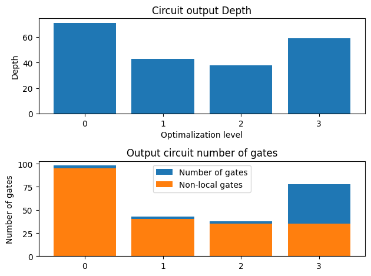

```python
ghz = qiskit.QuantumCircuit(15)
ghz.h(0)
ghz.cx(0, range(1, 15))

depths = []
gate_counts = []
non_local_gate_counts = []
levels = [str(x) for x in range(4)]
for level in range(4):
     circ = qiskit.transpile(ghz, backend, optimization_level=level)
     depths.append(circ.depth())
     gate_counts.append(sum(circ.count_ops().values()))
     non_local_gate_counts.append(circ.num_nonlocal_gates())
fig, (ax1, ax2) = plt.subplots(2, 1)
ax1.bar(levels, depths, label='Depth')
ax1.set_xlabel("Optimalization level")
ax1.set_ylabel("Depth")
ax1.set_title("Circuit output Depth")
ax2.bar(levels, gate_counts, label='Number of gates')
ax2.bar(levels, non_local_gate_counts, label='Non-local gates')
ax1.set_xlabel("Optimalization level")
ax2.set_ylabel("Number of gates")
ax2.legend()
ax2.set_title("Output circuit number of gates")
fig.tight_layout()
plt.show()
```